# NYPD Shooting Incidents

Carlos Barron

2022-01-16

## Libraries

First I will import the libraries I will use for my report.

```r
library(tidyverse)
library(knitr)
library(lubridate)
library(ggplot2)
```

## Introduction

This notebook is an initial analysis and exploration of the shooting incidents in the city of New York, it contains the list of every shooting incident that occurred in New York City going back to 2006.

## Data Source

The data can be found in the NYC Open Data site: (https://data.cityofnewyork.us) I will be using the NYPD shooting incident data set, the data contained is a breakdown of every shooting incident that occurred in NYC going back to 2006

First let’s download the data: (https://data.cityofnewyork.us/api/views/833y-fsy8/rows.csv?accessType=DOWNLOAD)

```r
nypd_data = read_csv('https://data.cityofnewyork.us/api/views/833y-fsy8/rows.csv?accessType=DOWNLOAD')
```

Let’s take a quick look into the different columns:

```r
glimpse(nypd_data)
```

```
## Rows: 25,596
## Columns: 19
## $ INCIDENT_KEY            <dbl> 236168668, 231008085, 230717903, 237712309, 22…
## $ OCCUR_DATE              <chr> "11/11/2021", "07/16/2021", "07/11/2021", "12/…
## $ OCCUR_TIME              <time> 15:04:00, 22:05:00, 01:09:00, 13:42:00, 20:00…
## $ BORO                    <chr> "BROOKLYN", "BROOKLYN", "BROOKLYN", "BROOKLYN"…
## $ PRECINCT                <dbl> 79, 72, 79, 81, 113, 113, 42, 52, 34, 75, 32, …
## $ JURISDICTION_CODE       <dbl> 0, 0, 0, 0, 0, 0, 0, 0, 0, 0, 0, 2, 2, 0, 0, 0…
## $ LOCATION_DESC           <chr> NA, NA, NA, NA, NA, NA, "COMMERCIAL BLDG", NA,…
## $ STATISTICAL_MURDER_FLAG <lgl> FALSE, FALSE, FALSE, FALSE, FALSE, TRUE, TRUE,…
## $ PERP_AGE_GROUP          <chr> NA, "45-64", "<18", NA, NA, NA, NA, NA, NA, "2…
## $ PERP_SEX                <chr> NA, "M", "M", NA, NA, NA, NA, NA, NA, "M", "M"…
## $ PERP_RACE               <chr> NA, "ASIAN / PACIFIC ISLANDER", "BLACK", NA, N…
## $ VIC_AGE_GROUP           <chr> "18-24", "25-44", "25-44", "25-44", "25-44", "…
## $ VIC_SEX                 <chr> "M", "M", "M", "M", "M", "M", "M", "M", "M", "…
## $ VIC_RACE                <chr> "BLACK", "ASIAN / PACIFIC ISLANDER", "BLACK", …
## $ X_COORD_CD              <dbl> 996313, 981845, 996546, 1001139, 1050710, 1051…
## $ Y_COORD_CD              <dbl> 187499, 171118, 187436, 192775, 184826, 196646…
## $ Latitude                <dbl> 40.68132, 40.63636, 40.68114, 40.69579, 40.673…
## $ Longitude               <dbl> -73.95651, -74.00867, -73.95567, -73.93910, -7…
## $ Lon_Lat                 <chr> "POINT (-73.95650899099996 40.68131820000008)"…
```

And an initial plot of the time of occurrance.

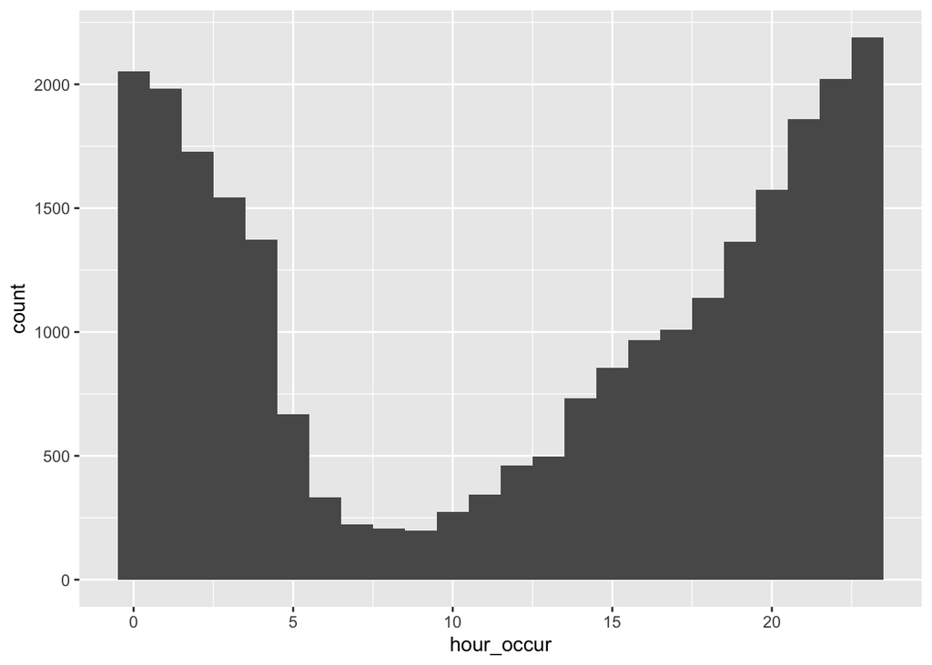

```r
hour_occur = hour(nypd_data$OCCUR_TIME)
df = data.frame(hour_occur)
ggplot(data=df, aes(x=hour_occur)) +
  stat_bin(bins = 24)
```

```r
  geom_histogram()
```

```
## geom_bar: na.rm = FALSE, orientation = NA
## stat_bin: binwidth = NULL, bins = NULL, na.rm = FALSE, orientation = NA, pad = FALSE
## position_stack
```

It looks like shootings dramatically increase when dark.

## Variables

Then I will create some variables for manipulation and categorization of data. - The important one here will be time of day.

```r
time_shifts = hour(hm("00:00","5:00","12:00","16:00","23:59"))
time_of_day = c("Night", "Morning", "Afternoon", "Evening")
q = setNames( rep(c('Winter', 'Spring', 'Summer','Fall'),each=3), c(12,1:11))
```

### Dataset cleanup

I will not use Lon_Lat, X_COORD_CD, Y_COORD_CD, VIC_RACE, PERP_RACE, LOCATION_DESC, JURISDICTION_CODE, PRECINCT so I will omit from my data set. I will create the new columns MONTH_NUM, change the date as type mdy, and set the time of day and season.

```r
nypd_data = nypd_data %>%
  mutate(
    MONTH_NUM = as.numeric(format(as.Date(OCCUR_DATE, '%m/%d/%Y'), '%m')),
    HOUR = as.numeric(hour(OCCUR_TIME)),
    OCCUR_DATE = mdy(OCCUR_DATE),
    TIME_OF_DAY = cut(x=hour(OCCUR_TIME), breaks = time_shifts, labels = time_of_day, include.lowest=TRUE),
    SEASON = unname(q[as.character(MONTH_NUM)]),
    ) %>%
  rename(DATE = 'OCCUR_DATE',
         TIME = 'OCCUR_TIME',
         ID = 'INCIDENT_KEY') %>%
  select(-c(Lon_Lat, X_COORD_CD, Y_COORD_CD, VIC_RACE,
            PERP_RACE, LOCATION_DESC, JURISDICTION_CODE, PRECINCT))
```

Then I set my model on the TIME_SQ column as a quadratic function, since I believe it adapts much better than a linear function.

```r
shootings_by_time_of_day = nypd_data %>% group_by(TIME_OF_DAY, TIME, HOUR, BORO, SEASON) %>% summarize(CASES = sum(Latitude/Latitude), MURDERS = sum(STATISTICAL_MURDER_FLAG), TIME_SQ = (((HOUR-11)^2)/8)+2) %>% select(TIME_OF_DAY, TIME, BORO, CASES, MURDERS, TIME_SQ, HOUR, SEASON)  %>% ungroup()
quadr = lm(CASES ~ TIME_SQ, data = shootings_by_time_of_day)
shootings_by_time_of_day = shootings_by_time_of_day %>% mutate(PREDICTION = predict(quadr))
shootings_by_season = nypd_data %>% group_by(SEASON, BORO) %>% summarize(CASES = sum(Latitude/Latitude), MURDERS = sum(STATISTICAL_MURDER_FLAG)) %>% select(SEASON,BORO, CASES, MURDERS) %>% ungroup()
```

## Data Summary

Here is a summary of the data by time of day and season:

```r
summary(shootings_by_time_of_day)
```

```
##     TIME_OF_DAY        TIME              BORO               CASES
##  Night    : 9347   Length:25596      Length:25596       Min.   : 1.000
##  Morning  : 2039   Class1:hms        Class :character   1st Qu.: 2.000
##  Afternoon: 3053   Class2:difftime   Mode  :character   Median : 3.000
##  Evening  :11157   Mode  :numeric                       Mean   : 4.805
##                                                         3rd Qu.: 6.000
##                                                         Max.   :34.000
##     MURDERS           TIME_SQ           HOUR          SEASON
##  Min.   : 0.0000   Min.   : 2.00   Min.   : 0.00   Length:25596
##  1st Qu.: 0.0000   1st Qu.: 6.50   1st Qu.: 3.00   Class :character
##  Median : 0.0000   Median :12.12   Median :15.00   Mode  :character
##  Mean   : 0.9556   Mean   :11.24   Mean   :12.19
##  3rd Qu.: 1.0000   3rd Qu.:14.50   3rd Qu.:20.00
##  Max.   :10.0000   Max.   :20.00   Max.   :23.00
##    PREDICTION
##  Min.   :2.648
##  1st Qu.:3.699
##  Median :5.012
##  Mean   :4.805
##  3rd Qu.:5.567
##  Max.   :6.851
```

```r
summary(shootings_by_season)
```

```
##     SEASON              BORO               CASES         MURDERS
##  Length:20          Length:20          Min.   : 157   Min.   : 34.0
##  Class :character   Class :character   1st Qu.: 686   1st Qu.:117.8
##  Mode  :character   Mode  :character   Median :1016   Median :190.0
##                                        Mean   :1280   Mean   :246.4
##                                        3rd Qu.:1800   3rd Qu.:351.5
##                                        Max.   :3642   Max.   :671.0
```

## Visualizations and Analysis

In the graphs it can be seen how there are more shootings during the evening and at night. During some seasons, there are less hours of sunlight, this could be affecting how my model is predicting incidents. It seems like during the summer more incidents occur.

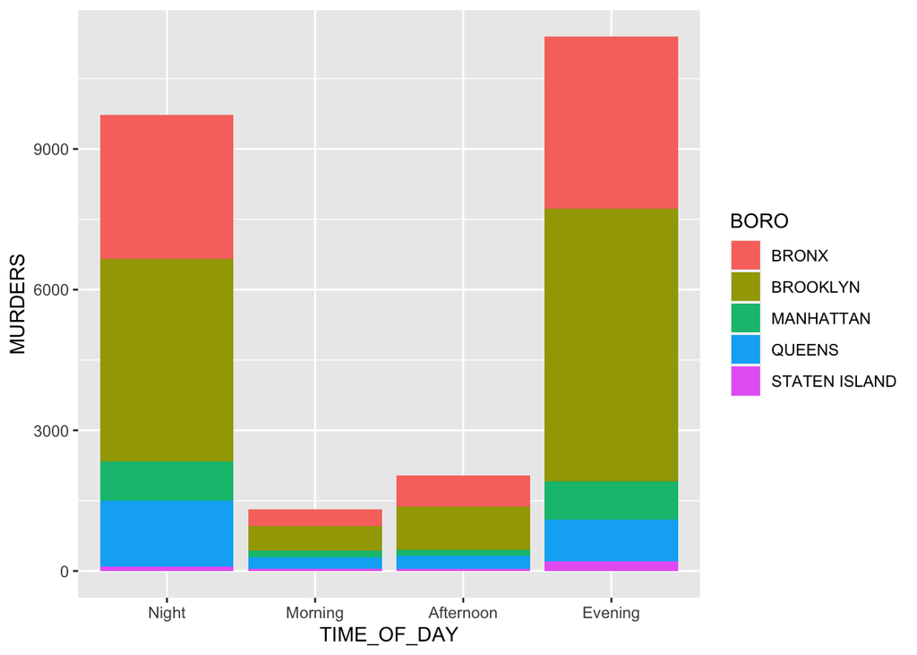

```r
ggplot2::ggplot(data = shootings_by_time_of_day) + geom_bar(mapping = aes(x=TIME_OF_DAY, y=MURDERS, fill=BORO), stat='identity')
```

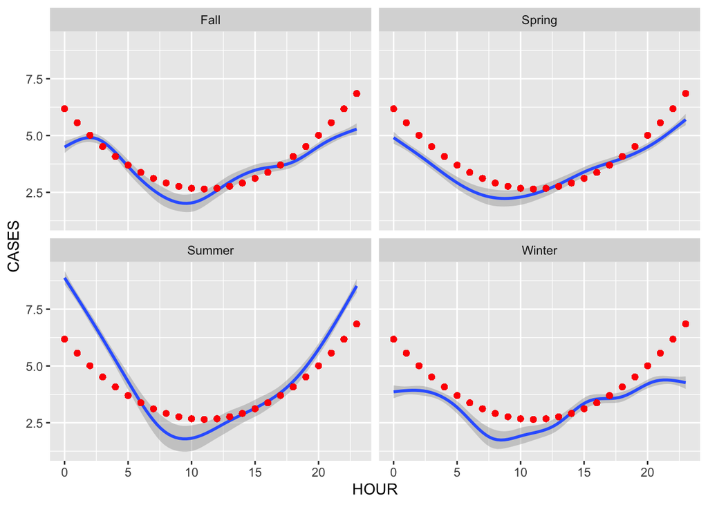

```r
# `geom_smooth()` using method = 'gam' and formula 'y ~ s(x, bs = "cs")'
ggplot2::ggplot(data = shootings_by_time_of_day) + geom_smooth(mapping = aes(x=HOUR, y=CASES)) + geom_point(aes(x=HOUR, y=PREDICTION), color='red') +facet_wrap(~ SEASON)
```

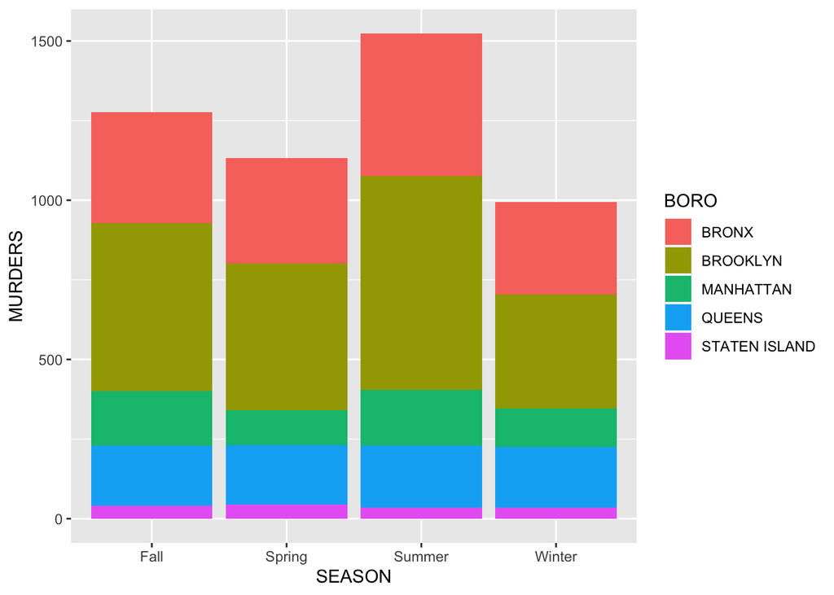

```r
ggplot2::ggplot(data = shootings_by_season) + geom_bar(mapping = aes(x=SEASON, y=MURDERS, fill=BORO), stat='identity')
```

## Bias & Conclusion

For this report I binned shooting events under 4 categories (night, morning, afternoon and evening), I also created some new categories by season (fall, spring, summer and winter). After some analysis and exploration, it can be inferred that there are higher chances of shootings at dark. This was an easy presumption to make, and using the visualizations presented before I was able to evaluate my presumption. In the data set there are columns for victim and perpetrator race, I believe this piece of information can always be a source of bias, but I believe it doesn’t affect my analysis with regards to time of the event. Another possible bias in my analysis could be the sunlight specific to NYC, since I have never lived in NYC I’m not able to clearly identify the time-sunlight relation as a local.